# Chapter 6

## Number of weeks, baseline (week 0) included

```r
n <- RATSL$Time %>% unique() %>% length()
```

```r
RATSS <- RATSL %>%
  group_by(Group, Time) %>%
  summarise( mean = mean(Weight), se = sd(Weight)/sqrt(n) ) %>%
  ungroup()
```

## Plot the mean profiles

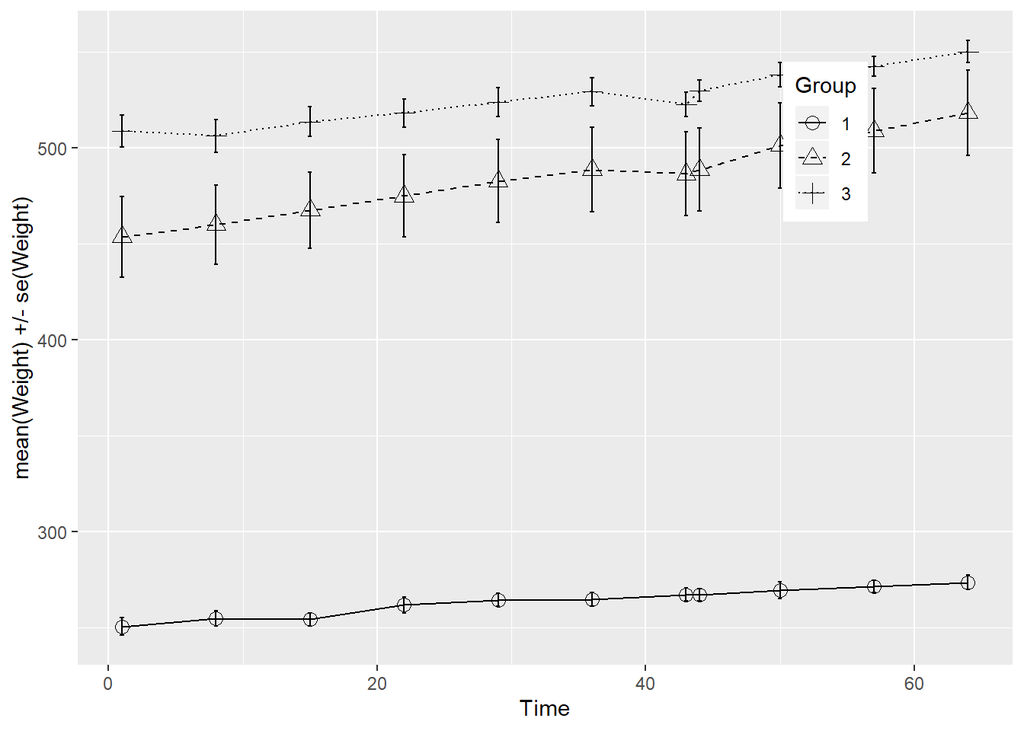

```r
ggplot(RATSS, aes(x = Time, y = mean, linetype = Group, shape = Group)) +
  geom_line() +
  scale_linetype_manual(values = c(1,2,3)) +
  geom_point(size=3) +
  scale_shape_manual(values = c(1,2,3)) +
  geom_errorbar(aes(ymin = mean - se, ymax = mean + se, linetype="1"), width=0.3) +
  theme(legend.position = c(0.8,0.8)) +
  scale_y_continuous(name = "mean(Weight) +/- se(Weight)")
```

*You can see the tha mean weight of the different groups increases over time.*

## Create a summary data by treatment and subject with mean as the summary variable (ignoring baseline week 0).

```r
RATSL8S <- RATSL %>%
  filter(Time > 0) %>%
  group_by(Group, ID) %>%
  summarise( mean=mean(Weight) ) %>%
  ungroup()
```

## Draw a boxplot of the mean versus treatment

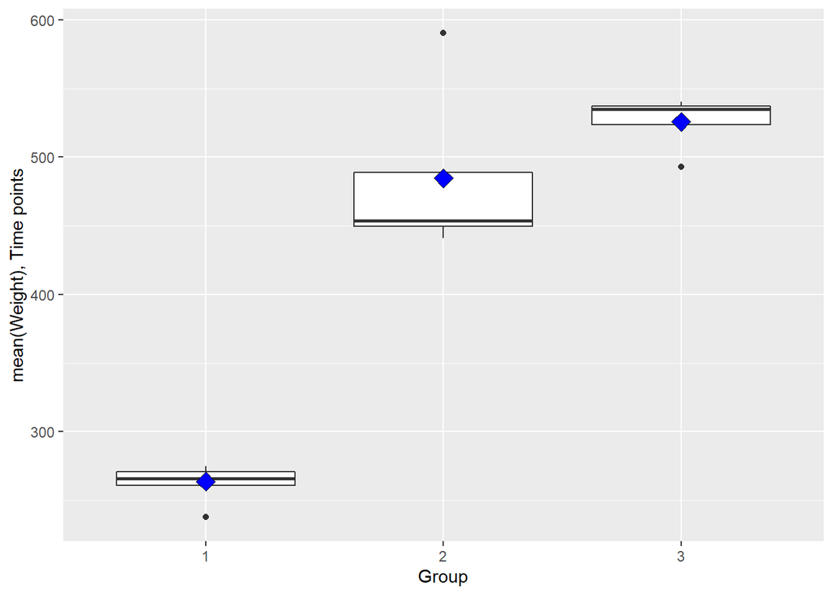

```r
ggplot(RATSL8S, aes(x = Group, y = mean)) +
  geom_boxplot() +
  stat_summary(fun.y = "mean", geom = "point", shape=23, size=4, fill = "blue") +
  scale_y_continuous(name = "mean(Weight), Time points")
```

*There appears to be an outlier for each group. They might bias the conclusions from further comparisons of the groups, so we shall remove that subject from the data.*

## Create a new data by filtering the outliers

```r
RATS1 <-subset( RATSL8S, Group == 1 )
RATS1 <- RATS1 %>% filter( mean < 300, mean > 250 )

RATS2 <- subset( RATSL8S, Group == 2 )
RATS2 <- RATS2 %>% filter( mean < 490, mean > 299 )

RATS3 <- subset( RATSL8S, Group == 3 )
RATS3 <- RATS3 %>% filter( mean < 550, mean > 500 )

RATSuber <- rbind( RATS1, RATS2, RATS3 )
```

## Adjust the ggplot code the draw the plot again with the new data

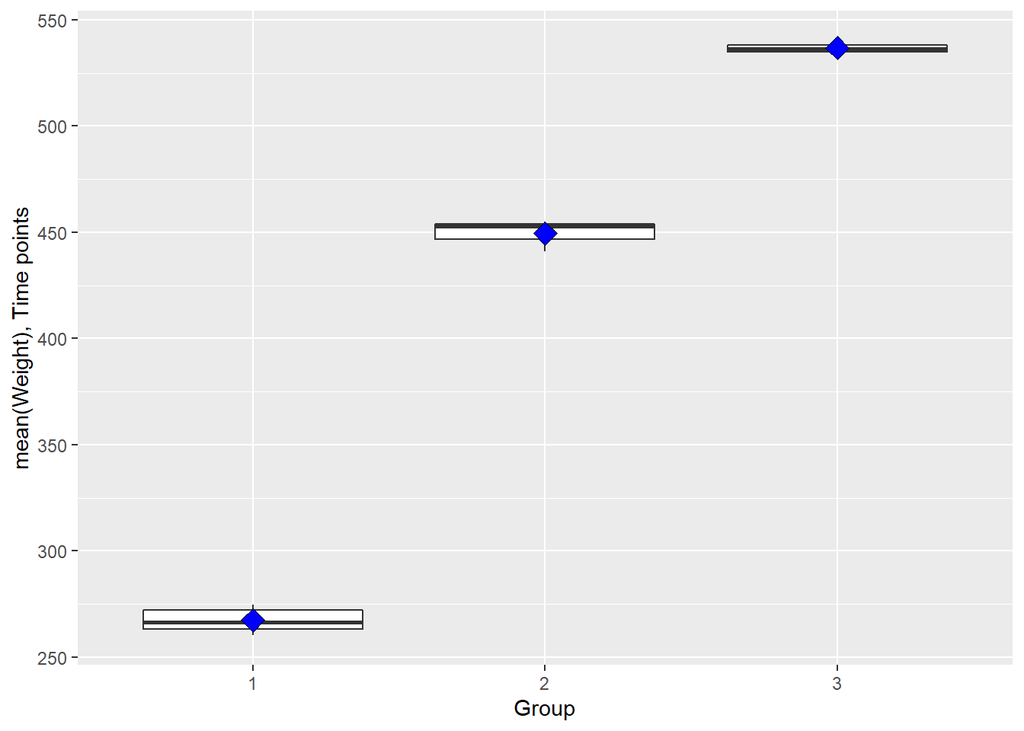

```r
ggplot(RATSuber, aes(x = Group, y = mean)) +
   geom_boxplot() +
   stat_summary(fun.y = "mean", geom = "point", shape=23, size=4, fill = "blue") +
   scale_y_continuous(name = "mean(Weight), Time points")
```

*Yahoo! we got rid to the outliers! it took a while and a round about way to do it but they are gone. There are 13 observations in the RATSuber Data. Since there are more than 2 groups, we are unable to run the T-test.*

## Add the baseline from the original data as a new variable to the summary data

```r
RATSL8S2 <- RATSL8S %>%
  mutate(baseline = RATS$WD1)
```

## Fit the linear model with the mean as the response

```r
fit <- lm(mean ~ baseline + Group, data = RATSL8S2)
```

## Compute the analysis of variance table for the fitted model with anova

```r
anova(fit)
```

|  | Df | Sum Sq | Mean Sq | F value | Pr(>F) |
| --- | --- | --- | --- | --- | --- |
| baseline | 1 | 252124.5433 | 252124.5433 | 2237.065461 | 5.216538e-15 |
| Group | 2 | 726.2362 | 363.1181 | 3.221896 | 7.585537e-02 |
| Residuals | 12 | 1352.4390 | 112.7032 | NA | NA |

*Using week1 as the baseline, the baseline RATS is strongly related to the Weight values taken after treatment has begun, but there is still no evidence of a treatment difference even after conditioning on the baseline value.*